# Ghana Scenario Planning Notes

Tim Essam, USAID GeoCenter

7/2/2019

#### GDP Growth and Inflation

- Average annual growth was 6.8 percent
- In 2017, Ghana was one of the fastest growing economies in the world
- Weaker fiscal and monetary policies, terms of trade shocks from lower oil prices, and electricity rationing slowed growth to an average of approximately 5 percent between 2014 and 2017

#### GDP Composition Driven by Services

- GDP is driven by services, comprising around 55% of GDP
- With the production of crude oil, industry has gradually expanded

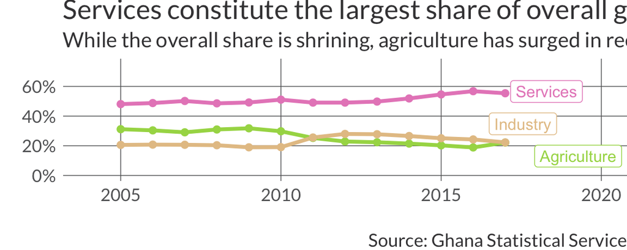

#### Poverty in Ghana is Greatest in the Upper West and North

- Economic growth between 2012/13 and 2016/17 has **not been pro-poor**
- The middle class benefitted from growth, while those at the bottom end of the distribution, especially the very poor, experienced a decline in consumption per adult equivalent over the four-year period
- Poverty is largely a rural phenomenom
- Even though poverty in the Upper West Region is the highest among the 10 regions, the region contributes less than 10 percent to national poverty because it is the smallest region in Ghana in terms of population.

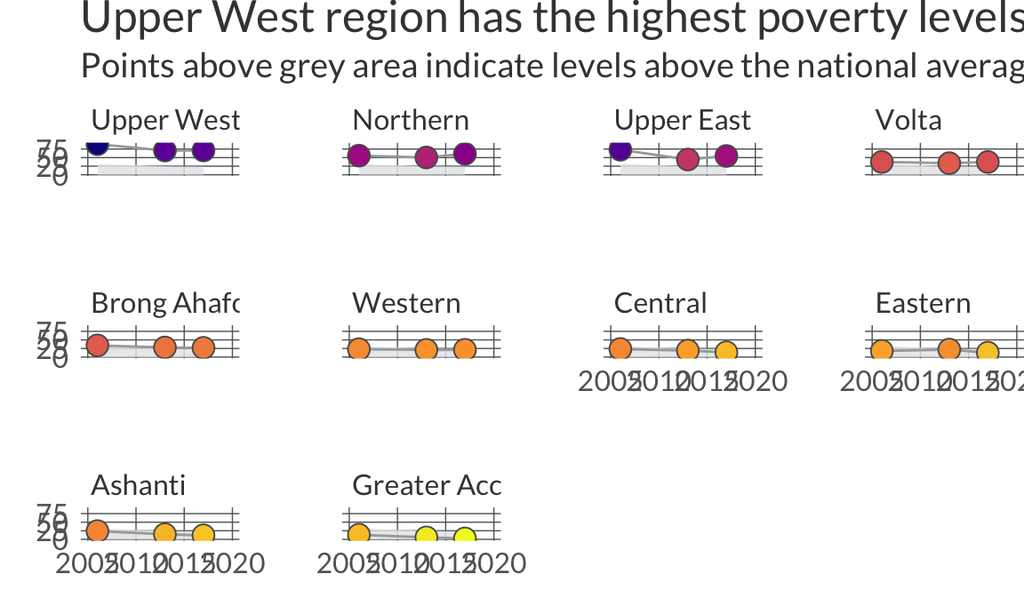

#### Inequality has Increased in the North

- Fundamental cause of rising poverty in the Volta and three Northern regions is lack of economic growth in these regions
- Inequality is highest in the Upper West and Northern Regions
- In the Northern Region and Upper East Region, poverty increased because both the growth and redistribution deteriorated

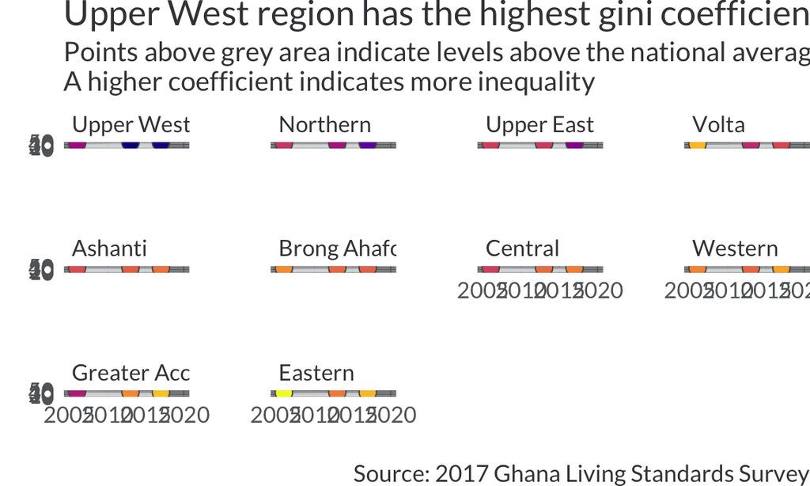

#### Human Development lags behind in the North

- Access to health services had declined over the years. The proportion of the ill or injured who are likely not to consult a doctor or even visit a health facility for treatment increased over the four-year period.
- Electricity access has steadily increased in the north but still lags behind
- Access to improved toilets are rare in Upper East and Upper West

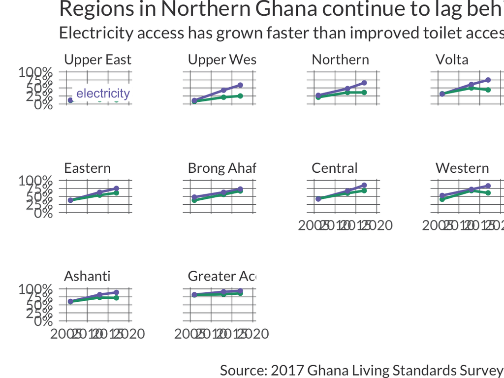

#### Fertility Indicators lag behind in the North

- Adolescent birth rates are highest in Volta and Western Region
- Demand for family planning and contraception use is lowest in Northern Region. As a result, total fertility rate is highest in this region.
- Upper East Region has high demand for family planning and modern contraception use.

[figure not shown]

#### Males Use more Information Communication Technology than Females

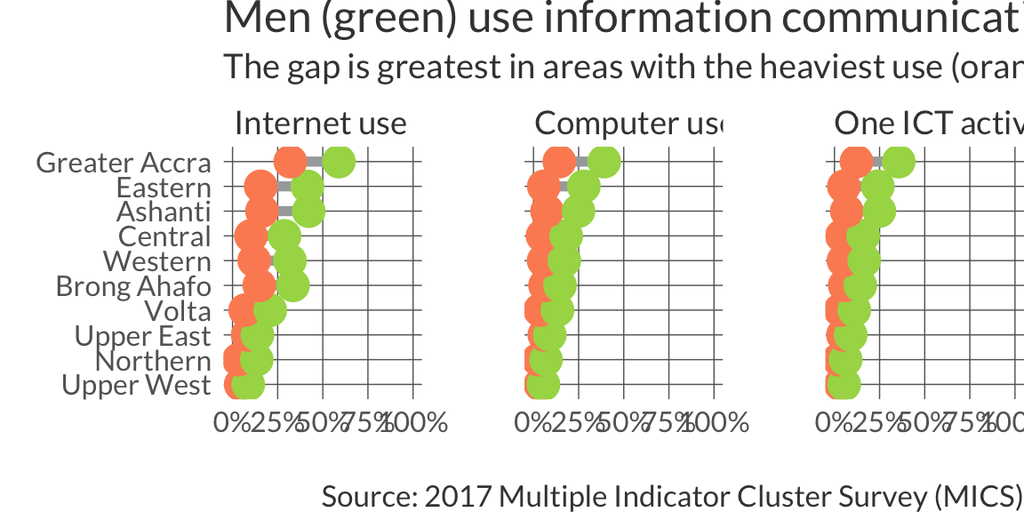

#### Delcining Chronic Child Malnutrition throughout Ghana

- Stunting has decline in recent years, but remains high in Northern Region
- Ghana has some of the lowest stunting rates in West Africa

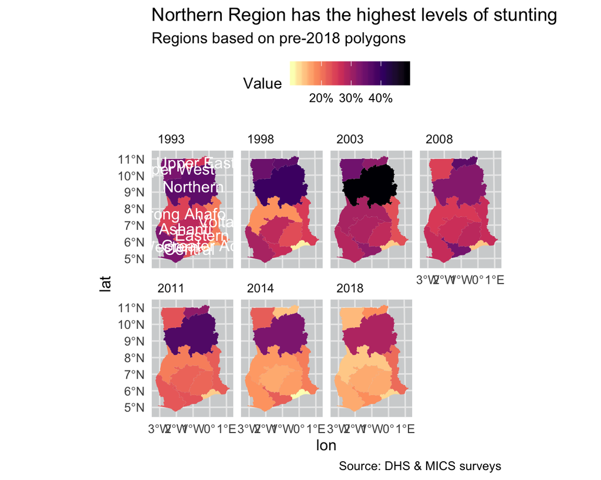

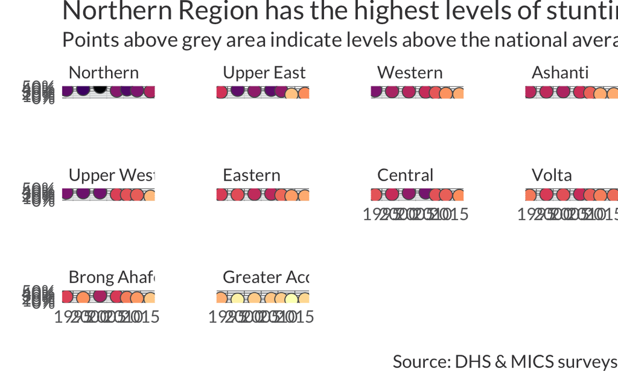

#### As of 2018, Ghana now has 16 Administrative Regions

- Statistics reported above are from surveys based on 10 administrative regions
- New surveys will likely be powered to be respresentative for each of the 16 regions
- This finer geographic detail will help further highlight geographic differences in development outcomes

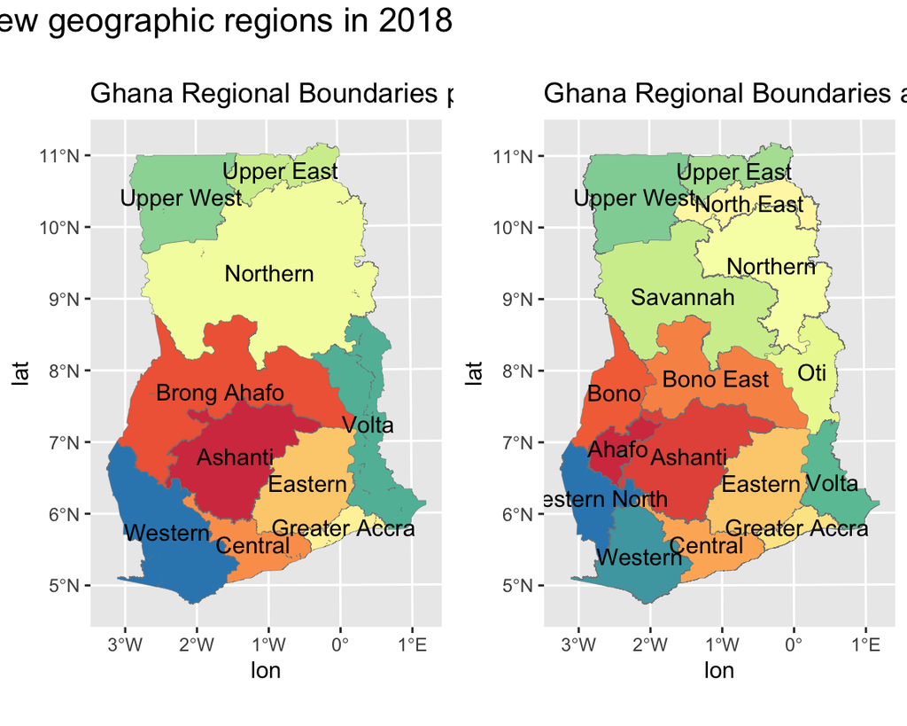